# Introduction

# Cook's distance

The next section deals with Cook's distance. It identifies any outliers in the each of the varaibles

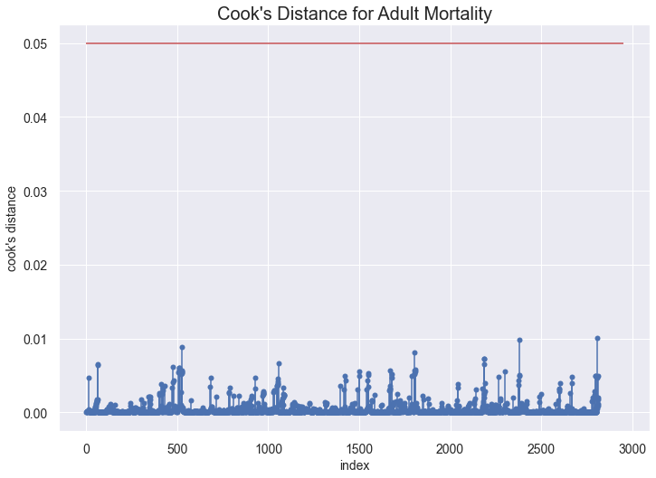

```python
#Import packages to do Cook's distance
import numpy as np
import pandas as pd
import statsmodels.api as sm
import matplotlib.pyplot as plt
from statsmodels.stats.outliers_influence import OLSInfluence

#Cook's distance for Adult Mortality
X = lifeexp_continent[['Adult Mortality']]
y = lifeexp_continent[['Life expectancy ']]
model = sm.OLS(y, sm.add_constant(X))
model_fit = model.fit()

cook_distance = OLSInfluence(model_fit).cooks_distance
(distance, p_value) = cook_distance

#####
threshold = 5/100

# stem plot - the x-axis represents the index of the observation and the y-axis its Cook's distance
plt.stem(distance, basefmt=" ", use_line_collection=True)

# horizontal line showing the threshold value
plt.hlines(threshold, -2, 2950, 'r')

# the observations with Cook's distances higher than the threshold value are labeled in the plot
influencial_data = distance[distance > threshold]

for index, value in influencial_data.items():
    plt.text(index, value, str(index), fontsize=10)

# ticks
plt.xticks(fontsize=14)
plt.yticks(fontsize=14)

# labels and title
plt.xlabel('index', fontsize=14)
plt.ylabel('cook\'s distance', fontsize=14)
plt.title('Cook\'s Distance for Adult Mortality', fontsize=20);
```

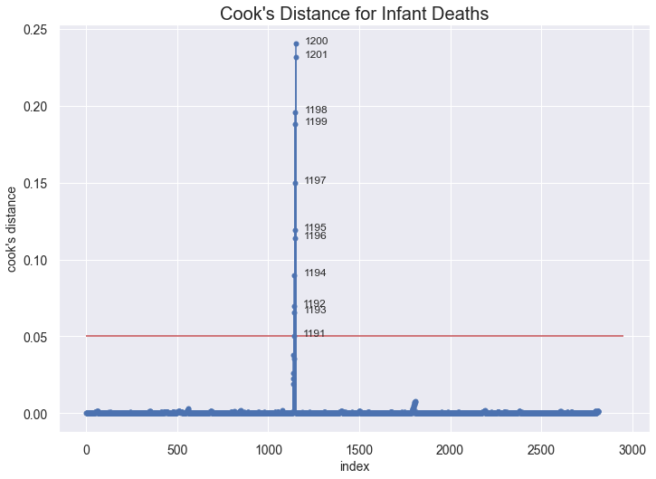

```python
#Cooks distance for Infant deaths
X = lifeexp_continent[['infant deaths']]
y = lifeexp_continent[['Life expectancy ']]
model = sm.OLS(y, sm.add_constant(X))
model_fit = model.fit()

cook_distance = OLSInfluence(model_fit).cooks_distance
(distance, p_value) = cook_distance

#####
threshold = 5/100

# stem plot - the x-axis represents the index of the observation and the y-axis its Cook's distance
plt.stem(distance, basefmt=" ", use_line_collection=True)

# horizontal line showing the threshold value
plt.hlines(threshold, -2, 2950, 'r')

# the observations with Cook's distances higher than the threshold value are labeled in the plot
influencial_data = distance[distance > threshold]

for index, value in influencial_data.items():
    plt.text(index, value, str(index), fontsize=12)

# ticks
plt.xticks(fontsize=14)
plt.yticks(fontsize=14)

# labels and title
plt.xlabel('index', fontsize=14)
plt.ylabel('cook\'s distance', fontsize=14)
plt.title('Cook\'s Distance for Infant Deaths', fontsize=20);
#India has the outliers
```

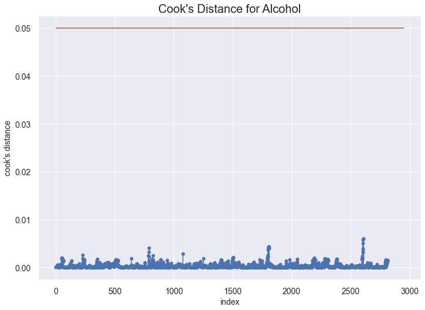

```python
#Cook's distance for Alcohol
X = lifeexp_continent[['Alcohol']]
y = lifeexp_continent[['Life expectancy ']]
model = sm.OLS(y, sm.add_constant(X))
model_fit = model.fit()

cook_distance = OLSInfluence(model_fit).cooks_distance
(distance, p_value) = cook_distance

#####
threshold = 5/100

# stem plot - the x-axis represents the index of the observation and the y-axis its Cook's distance
plt.stem(distance, basefmt=" ", use_line_collection=True)

# horizontal line showing the threshold value
plt.hlines(threshold, -2, 2950, 'r')

# the observations with Cook's distances higher than the threshold value are labeled in the plot
influencial_data = distance[distance > threshold]

for index, value in influencial_data.items():
    plt.text(index, value, str(index), fontsize=12)

# ticks
plt.xticks(fontsize=14)
plt.yticks(fontsize=14)

# labels and title
plt.xlabel('index', fontsize=14)
plt.ylabel('cook\'s distance', fontsize=14)
plt.title('Cook\'s Distance for Alcohol', fontsize=20);
```

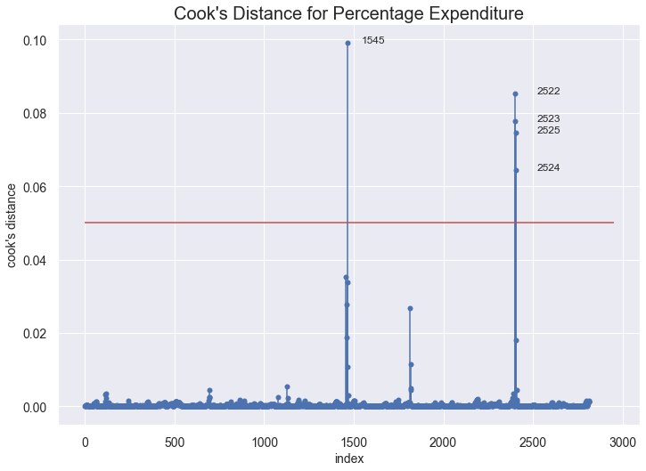

```python
#Cook's distance for percentage expenditure
X = lifeexp_continent[['percentage expenditure']]
y = lifeexp_continent[['Life expectancy ']]
model = sm.OLS(y, sm.add_constant(X))
model_fit = model.fit()

cook_distance = OLSInfluence(model_fit).cooks_distance
(distance, p_value) = cook_distance

#####
threshold = 5/100

# stem plot - the x-axis represents the index of the observation and the y-axis its Cook's distance
plt.stem(distance, basefmt=" ", use_line_collection=True)

# horizontal line showing the threshold value
plt.hlines(threshold, -2, 2950, 'r')

# the observations with Cook's distances higher than the threshold value are labeled in the plot
influencial_data = distance[distance > threshold]

for index, value in influencial_data.items():
    plt.text(index, value, str(index), fontsize=12)

# ticks
plt.xticks(fontsize=14)
plt.yticks(fontsize=14)

# labels and title
plt.xlabel('index', fontsize=14)
plt.ylabel('cook\'s distance', fontsize=14)
plt.title('Cook\'s Distance for Percentage Expenditure', fontsize=20);

#luxemborg, sweden, swizte
```

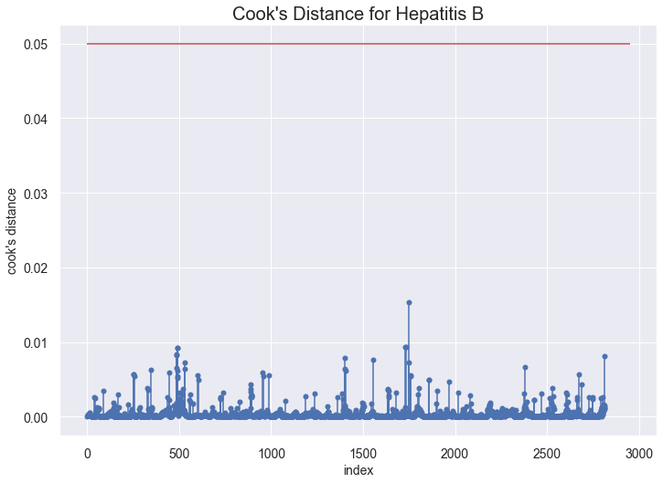

```python
#Cook's distance for Hepatitis B
X = lifeexp_continent[['Hepatitis B']]
y = lifeexp_continent[['Life expectancy ']]
model = sm.OLS(y, sm.add_constant(X))
model_fit = model.fit()

influence = model_fit.get_influence()

cook_distance = OLSInfluence(model_fit).cooks_distance
(distance, p_value) = cook_distance

#####
threshold = 5/100

# stem plot - the x-axis represents the index of the observation and the y-axis its Cook's distance
plt.stem(distance, basefmt=" ", use_line_collection=True)

# horizontal line showing the threshold value
plt.hlines(threshold, -2, 2950, 'r')

# the observations with Cook's distances higher than the threshold value are labeled in the plot
influencial_data = distance[distance > threshold]

for index, value in influencial_data.items():
    plt.text(index, value, str(index), fontsize=12)

# ticks
plt.xticks(fontsize=14)
plt.yticks(fontsize=14)

# labels and title
plt.xlabel('index', fontsize=14)
plt.ylabel('cook\'s distance', fontsize=14)
plt.title('Cook\'s Distance for Hepatitis B', fontsize=20);
```

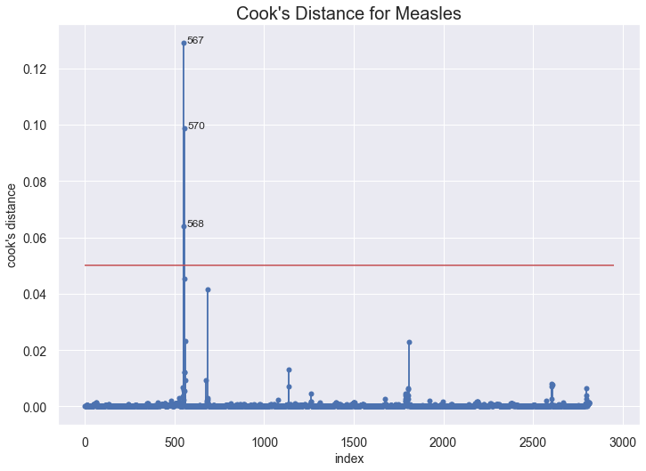

```python
#Cook's distance for Measles
X = lifeexp_continent[['Measles ']]
y = lifeexp_continent[['Life expectancy ']]
model = sm.OLS(y, sm.add_constant(X))
model_fit = model.fit()

cook_distance = OLSInfluence(model_fit).cooks_distance
(distance, p_value) = cook_distance

plt.stem(np.arange(len(distance)), distance,use_line_collection = True,markerfmt=",")
plt.title('Cook\'s distance for measles')

#####
threshold = 5/100

# stem plot - the x-axis represents the index of the observation and the y-axis its Cook's distance
plt.stem(distance, basefmt=" ", use_line_collection=True)

# horizontal line showing the threshold value
plt.hlines(threshold, -2, 2950, 'r')

# the observations with Cook's distances higher than the threshold value are labeled in the plot
influencial_data = distance[distance > threshold]

for index, value in influencial_data.items():
    plt.text(index, value, str(index), fontsize=12)

# ticks
plt.xticks(fontsize=14)
plt.yticks(fontsize=14)

# labels and title
plt.xlabel('index', fontsize=14)
plt.ylabel('cook\'s distance', fontsize=14)
plt.title('Cook\'s Distance for Measles', fontsize=20);
#China
```

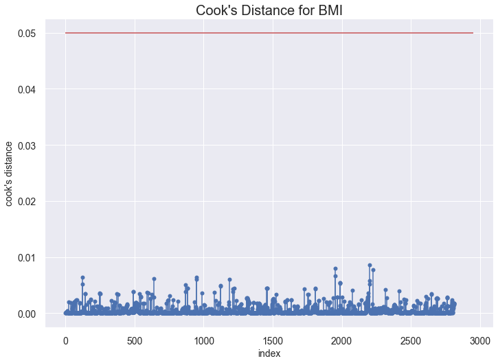

```python
#Cooks' distance for BMI
X = lifeexp_continent[[' BMI ']]
y = lifeexp_continent[['Life expectancy ']]
model = sm.OLS(y, sm.add_constant(X))
model_fit = model.fit()

cook_distance = OLSInfluence(model_fit).cooks_distance
(distance, p_value) = cook_distance

#####
threshold = 5/100

# stem plot - the x-axis represents the index of the observation and the y-axis its Cook's distance
plt.stem(distance, basefmt=" ", use_line_collection=True)

# horizontal line showing the threshold value
plt.hlines(threshold, -2, 2950, 'r')

# the observations with Cook's distances higher than the threshold value are labeled in the plot
influencial_data = distance[distance > threshold]

for index, value in influencial_data.items():
    plt.text(index, value, str(index), fontsize=12)

# ticks
plt.xticks(fontsize=14)
plt.yticks(fontsize=14)

# labels and title
plt.xlabel('index', fontsize=14)
plt.ylabel('cook\'s distance', fontsize=14)
plt.title('Cook\'s Distance for BMI', fontsize=20);
#df.loc[index]['Country']
```

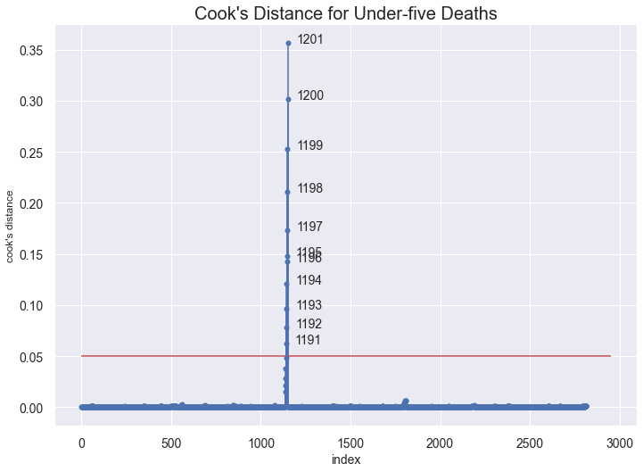

```python
#Cook's distance for under-five deaths
X = lifeexp_continent[['under-five deaths ']]
y = lifeexp_continent[['Life expectancy ']]
model = sm.OLS(y, sm.add_constant(X))
model_fit = model.fit()

cook_distance = OLSInfluence(model_fit).cooks_distance
(distance, p_value) = cook_distance

#####
threshold = 5/100

# stem plot - the x-axis represents the index of the observation and the y-axis its Cook's distance
plt.stem(distance, basefmt=" ", use_line_collection=True)

# horizontal line showing the threshold value
plt.hlines(threshold, -2, 2950, 'r')

# the observations with Cook's distances higher than the threshold value are labeled in the plot
influencial_data = distance[distance > threshold]

for index, value in influencial_data.items():
    plt.text(index, value, str(index), fontsize=14)

# ticks
plt.xticks(fontsize=14)
plt.yticks(fontsize=14)

# labels and title
plt.xlabel('index', fontsize=14)
plt.ylabel('cook\'s distance', fontsize=12)

plt.title('Cook\'s Distance for Under-five Deaths', fontsize=20)
#India
```

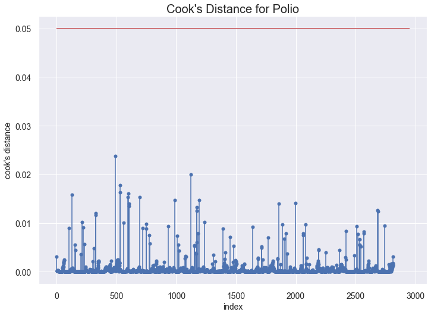

```python
#Cook's distance for Polio
X = lifeexp_continent[['Polio']]
y = lifeexp_continent[['Life expectancy ']]
model = sm.OLS(y, sm.add_constant(X))
model_fit = model.fit()

cook_distance = OLSInfluence(model_fit).cooks_distance
(distance, p_value) = cook_distance

#####
threshold = 5/100

# stem plot - the x-axis represents the index of the observation and the y-axis its Cook's distance
plt.stem(distance, basefmt=" ", use_line_collection=True)

# horizontal line showing the threshold value
plt.hlines(threshold, -2, 2950, 'r')

# the observations with Cook's distances higher than the threshold value are labeled in the plot
influencial_data = distance[distance > threshold]

for index, value in influencial_data.items():
    plt.text(index, value, str(index), fontsize=12)

# ticks
plt.xticks(fontsize=14)
plt.yticks(fontsize=14)

# labels and title
plt.xlabel('index', fontsize=14)
plt.ylabel('cook\'s distance', fontsize=14)

plt.title('Cook\'s Distance for Polio', fontsize=20)
```

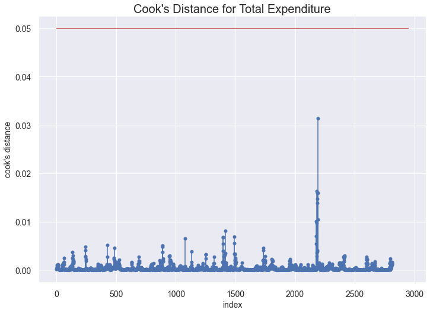

```python
#Cook's distance for total expenditure
X = lifeexp_continent[['Total expenditure']]
y = lifeexp_continent[['Life expectancy ']]
model = sm.OLS(y, sm.add_constant(X))
model_fit = model.fit()

cook_distance = OLSInfluence(model_fit).cooks_distance
(distance, p_value) = cook_distance

#####
threshold = 5/100

# stem plot - the x-axis represents the index of the observation and the y-axis its Cook's distance
plt.stem(distance, basefmt=" ", use_line_collection=True)

# horizontal line showing the threshold value
plt.hlines(threshold, -2, 2950, 'r')

# the observations with Cook's distances higher than the threshold value are labeled in the plot
influencial_data = distance[distance > threshold]

for index, value in influencial_data.items():
    plt.text(index, value, str(index), fontsize=12)

# ticks
plt.xticks(fontsize=14)
plt.yticks(fontsize=14)

# labels and title
plt.xlabel('index', fontsize=14)
plt.ylabel('cook\'s distance', fontsize=14)

plt.title('Cook\'s Distance for Total Expenditure', fontsize=20)
```

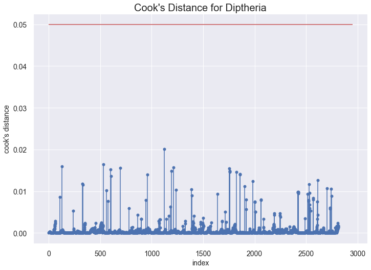

```python
#Cook's distance for Diphtheria
X = lifeexp_continent[['Diphtheria ']]
y = lifeexp_continent[['Life expectancy ']]
model = sm.OLS(y, sm.add_constant(X))
model_fit = model.fit()

cook_distance = OLSInfluence(model_fit).cooks_distance
(distance, p_value) = cook_distance

#####
threshold = 5/100

# stem plot - the x-axis represents the index of the observation and the y-axis its Cook's distance
plt.stem(distance, basefmt=" ", use_line_collection=True)

# horizontal line showing the threshold value
plt.hlines(threshold, -2, 2950, 'r')

# the observations with Cook's distances higher than the threshold value are labeled in the plot
influencial_data = distance[distance > threshold]

for index, value in influencial_data.items():
    plt.text(index, value, str(index), fontsize=12)

# ticks
plt.xticks(fontsize=14)
plt.yticks(fontsize=14)

# labels and title
plt.xlabel('index', fontsize=14)
plt.ylabel('cook\'s distance', fontsize=14)

plt.title('Cook\'s Distance for Diptheria', fontsize=20)
```

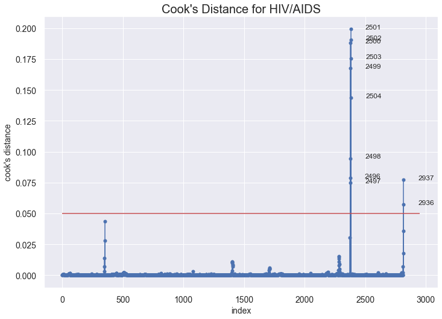

```python
#Cook's distance for HIV/AIDS
X = lifeexp_continent[[' HIV/AIDS']]
y = lifeexp_continent[['Life expectancy ']]
model = sm.OLS(y, sm.add_constant(X))
model_fit = model.fit()

cook_distance = OLSInfluence(model_fit).cooks_distance
(distance, p_value) = cook_distance



#####
threshold = 5/100

# stem plot - the x-axis represents the index of the observation and the y-axis its Cook's distance
plt.stem(distance, basefmt=" ", use_line_collection=True)

# horizontal line showing the threshold value
plt.hlines(threshold, -2, 2950, 'r')

# the observations with Cook's distances higher than the threshold value are labeled in the plot
influencial_data = distance[distance > threshold]

for index, value in influencial_data.items():
    plt.text(index, value, str(index), fontsize=12)

# ticks
plt.xticks(fontsize=14)
plt.yticks(fontsize=14)

# labels and title
plt.xlabel('index', fontsize=14)
plt.ylabel('cook\'s distance', fontsize=14)
plt.title('Cook\'s Distance for HIV/AIDS', fontsize=20)

#swaziland zimbabwe
```

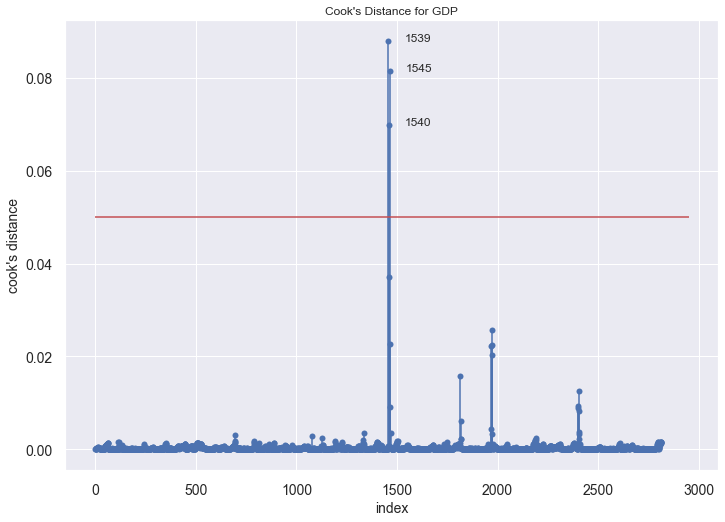

```python
#Cook's distance for GDP
X = lifeexp_continent[['GDP']]
y = lifeexp_continent[['Life expectancy ']]
model = sm.OLS(y, sm.add_constant(X))
model_fit = model.fit()

cook_distance = OLSInfluence(model_fit).cooks_distance
(distance, p_value) = cook_distance

#####
threshold = 5/100

# stem plot - the x-axis represents the index of the observation and the y-axis its Cook's distance
plt.stem(distance, basefmt=" ", use_line_collection=True)

# horizontal line showing the threshold value
plt.hlines(threshold, -2, 2950, 'r')

# the observations with Cook's distances higher than the threshold value are labeled in the plot
influencial_data = distance[distance > threshold]

for index, value in influencial_data.items():
    plt.text(index, value, str(index), fontsize=12)

# ticks
plt.xticks(fontsize=14)
plt.yticks(fontsize=14)

# labels and title
plt.xlabel('index', fontsize=14)
plt.ylabel('cook\'s distance', fontsize=14)

plt.title('Cook\'s distance for total expenditure', fontsize=20)

plt.title('Cook\'s Distance for GDP')
#lithunia luxemborg
```

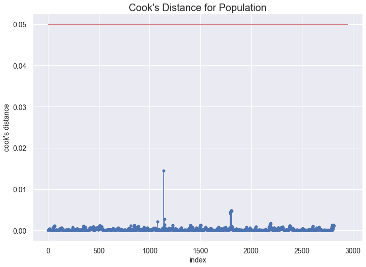

```python
#Cook's distance for population
X = lifeexp_continent[['Population']]
y = lifeexp_continent[['Life expectancy ']]
model = sm.OLS(y, sm.add_constant(X))
model_fit = model.fit()

cook_distance = OLSInfluence(model_fit).cooks_distance
(distance, p_value) = cook_distance

#####
threshold = 5/100

# stem plot - the x-axis represents the index of the observation and the y-axis its Cook's distance
plt.stem(distance, basefmt=" ", use_line_collection=True)

# horizontal line showing the threshold value
plt.hlines(threshold, -2, 2950, 'r')

# the observations with Cook's distances higher than the threshold value are labeled in the plot
influencial_data = distance[distance > threshold]

for index, value in influencial_data.items():
    plt.text(index, value, str(index), fontsize=12)

# ticks
plt.xticks(fontsize=14)
plt.yticks(fontsize=14)

# labels and title
plt.xlabel('index', fontsize=14)
plt.ylabel('cook\'s distance', fontsize=14)
plt.title('Cook\'s Distance for Population', fontsize=20)
```

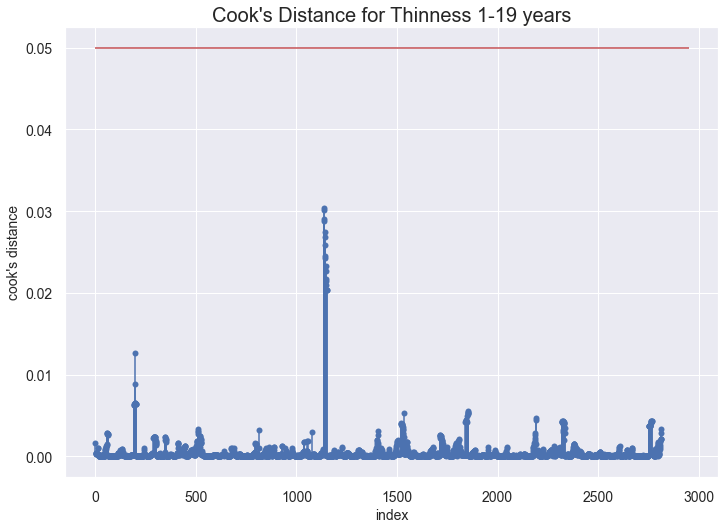

```python
#Cook's distance for thinness  1-19 years
X = lifeexp_continent[[' thinness  1-19 years']]
y = lifeexp_continent[['Life expectancy ']]
model = sm.OLS(y, sm.add_constant(X))
model_fit = model.fit()

cook_distance = OLSInfluence(model_fit).cooks_distance
(distance, p_value) = cook_distance

#####
threshold = 5/100

# stem plot - the x-axis represents the index of the observation and the y-axis its Cook's distance
plt.stem(distance, basefmt=" ", use_line_collection=True)

# horizontal line showing the threshold value
plt.hlines(threshold, -2, 2950, 'r')

# the observations with Cook's distances higher than the threshold value are labeled in the plot
influencial_data = distance[distance > threshold]

for index, value in influencial_data.items():
    plt.text(index, value, str(index), fontsize=12)

# ticks
plt.xticks(fontsize=14)
plt.yticks(fontsize=14)

# labels and title
plt.xlabel('index', fontsize=14)
plt.ylabel('cook\'s distance', fontsize=14)
plt.title('Cook\'s Distance for Thinness 1-19 years', fontsize=20)
```

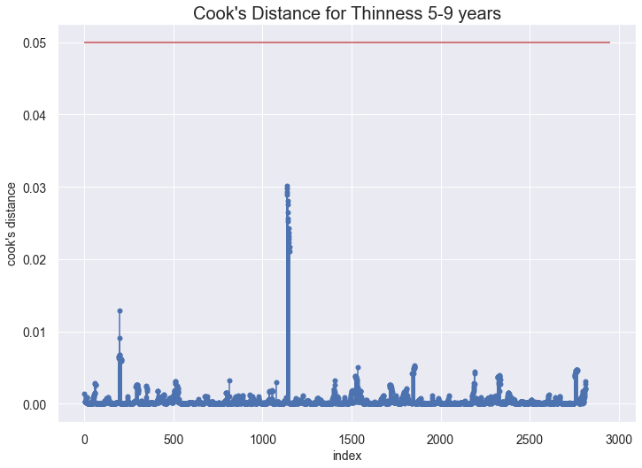

```python
#Cook's distance for thinness 5-9 years
X = lifeexp_continent[[' thinness 5-9 years']]
y = lifeexp_continent[['Life expectancy ']]
model = sm.OLS(y, sm.add_constant(X))
model_fit = model.fit()

cook_distance = OLSInfluence(model_fit).cooks_distance
(distance, p_value) = cook_distance

#####
threshold = 5/100

# stem plot - the x-axis represents the index of the observation and the y-axis its Cook's distance
plt.stem(distance, basefmt=" ", use_line_collection=True)

# horizontal line showing the threshold value
plt.hlines(threshold, -2, 2950, 'r')

# the observations with Cook's distances higher than the threshold value are labeled in the plot
influencial_data = distance[distance > threshold]

for index, value in influencial_data.items():
    plt.text(index, value, str(index), fontsize=12)

# ticks
plt.xticks(fontsize=14)
plt.yticks(fontsize=14)

# labels and title
plt.xlabel('index', fontsize=14)
plt.ylabel('cook\'s distance', fontsize=14)
plt.title('Cook\'s Distance for Thinness 5-9 years',fontsize=20)
```

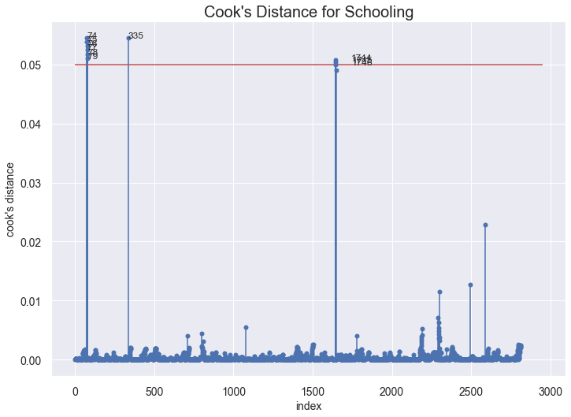

```python
#Cook's distance for Schooling
X = lifeexp_continent[['Schooling']]
y = lifeexp_continent[['Life expectancy ']]
model = sm.OLS(y, sm.add_constant(X))
model_fit = model.fit()


cook_distance = OLSInfluence(model_fit).cooks_distance
(distance, p_value) = cook_distance



#####
threshold = 5/100

# stem plot - the x-axis represents the index of the observation and the y-axis its Cook's distance
plt.stem(distance, basefmt=" ", use_line_collection=True)

# horizontal line showing the threshold value
plt.hlines(threshold, -2, 2950, 'r')

# the observations with Cook's distances higher than the threshold value are labeled in the plot
influencial_data = distance[distance > threshold]

for index, value in influencial_data.items():
    plt.text(index, value, str(index), fontsize=12)

# ticks
plt.xticks(fontsize=14)
plt.yticks(fontsize=14)

# labels and title
plt.xlabel('index', fontsize=14)
plt.ylabel('cook\'s distance', fontsize=14)
plt.title('Cook\'s Distance for Schooling', fontsize=20)
```

```python
#removed variables with high multicollinearity
import pandas as pd
import numpy as np
import statsmodels.api as sm
from statsmodels.formula.api import ols
from sklearn.model_selection import train_test_split

# Analysis of Variance (ANOVA) on linear models
from statsmodels.stats.anova import anova_lm

X = lifeexp_continent[['Status','Adult Mortality','Alcohol','percentage expenditure','Hepatitis B','Measles ',
' BMI ','Polio','Total expenditure','Diphtheria ',' HIV/AIDS',
'GDP','Population','Income composition of resources','Schooling']]
y = lifeexp_continent[['Life expectancy ']]

X_train, X_test, y_train, y_test = train_test_split(X, y, test_size=0.33)

## fit a OLS model training data
X = sm.add_constant(X_train)
est = sm.OLS(y_train, X).fit()
est.summary()

## fit a OLS model testing data
X = sm.add_constant(X_test)
est = sm.OLS(y_test, X).fit()
est.summary()
```

OLS Regression Results

| Dep. Variable: | Life expectancy | R-squared: | 0.811 |
| --- | --- | --- | --- |
| Model: | OLS | Adj. R-squared: | 0.807 |
| Method: | Least Squares | F-statistic: | 260.7 |
| Date: | Mon, 25 Oct 2021 | Prob (F-statistic): | 1.95e-317 |
| Time: | 10:51:32 | Log-Likelihood: | -2665.6 |
| No. Observations: | 930 | AIC: | 5363. |
| Df Residuals: | 914 | BIC: | 5441. |
| Df Model: | 15 |  |  |
| Covariance Type: | nonrobust |  |  |

|  | coef | std err | t | P>\|t\| | [0.025 | 0.975] |
| --- | --- | --- | --- | --- | --- | --- |
| const | 51.1989 | 0.978 | 52.371 | 0.000 | 49.280 | 53.118 |
| Status | 1.4827 | 0.515 | 2.882 | 0.004 | 0.473 | 2.493 |
| Adult Mortality | -0.0196 | 0.001 | -13.418 | 0.000 | -0.022 | -0.017 |
| Alcohol | 0.0713 | 0.047 | 1.507 | 0.132 | -0.022 | 0.164 |
| percentage expenditure | -2.47e-05 | 0.000 | -0.161 | 0.872 | -0.000 | 0.000 |
| Hepatitis B | -0.0226 | 0.008 | -2.946 | 0.003 | -0.038 | -0.008 |
| Measles | -5.409e-05 | 1.46e-05 | -3.704 | 0.000 | -8.28e-05 | -2.54e-05 |
| BMI | 0.0530 | 0.009 | 6.035 | 0.000 | 0.036 | 0.070 |
| Polio | 0.0471 | 0.009 | 5.276 | 0.000 | 0.030 | 0.065 |
| Total expenditure | 0.0280 | 0.066 | 0.425 | 0.671 | -0.101 | 0.157 |
| Diphtheria | 0.0547 | 0.009 | 5.823 | 0.000 | 0.036 | 0.073 |
| HIV/AIDS | -0.4892 | 0.033 | -14.822 | 0.000 | -0.554 | -0.424 |
| GDP | 4.34e-05 | 2.44e-05 | 1.776 | 0.076 | -4.56e-06 | 9.14e-05 |
| Population | 7.125e-09 | 6.51e-09 | 1.094 | 0.274 | -5.66e-09 | 1.99e-08 |
| Income composition of resources | 6.5689 | 1.184 | 5.550 | 0.000 | 4.246 | 8.892 |
| Schooling | 0.6859 | 0.080 | 8.585 | 0.000 | 0.529 | 0.843 |

| Omnibus: | 69.884 | Durbin-Watson: | 2.038 |
| --- | --- | --- | --- |
| Prob(Omnibus): | 0.000 | Jarque-Bera (JB): | 216.305 |
| Skew: | -0.333 | Prob(JB): | 1.07e-47 |
| Kurtosis: | 5.267 | Cond. No. | 2.13e+08 |

Notes:  
[1] Standard Errors assume that the covariance matrix of the errors is correctly specified.  
[2] The condition number is large, 2.13e+08. This might indicate that there are  
strong multicollinearity or other numerical problems.

```python
#VIF analysis
X = lifeexp_continent[['Status','Adult Mortality','Alcohol','percentage expenditure','Hepatitis B','Measles ',
' BMI ','Polio','Total expenditure','Diphtheria ',' HIV/AIDS',
'GDP','Population','Income composition of resources','Schooling']]
vif_data = pd.DataFrame()
vif_data["feature"] = X.columns

# calculating VIF for each feature
vif_data["VIF"] = [variance_inflation_factor(X.values, i)
                          for i in range(len(X.columns))]

print(vif_data)
```

```
                            feature        VIF
0                            Status   2.208420
1                   Adult Mortality   3.604709
2                           Alcohol   4.137835
3            percentage expenditure   5.869325
4                       Hepatitis B  17.234856
5                          Measles    1.127326
6                              BMI    7.165208
7                             Polio  24.816547
8                 Total expenditure   7.867782
9                       Diphtheria   27.985665
10                         HIV/AIDS   1.572136
11                              GDP   6.940778
12                       Population   1.130293
13  Income composition of resources  30.258242
14                        Schooling  44.522892
```

# Correlation Matrix

See which variables are correlated with each other or not correlated with each other. Variables not correlated with each other can be studied further.

```python
#Correlation matrix
lifeexp_continent.corr()
```

|  | Year | Status | Life expectancy | Adult Mortality | infant deaths | Alcohol | percentage expenditure | Hepatitis B | Measles | BMI | ... | Polio | Total expenditure | Diphtheria | HIV/AIDS | GDP | Population | thinness 1-19 years | thinness 5-9 years | Income composition of resources | Schooling |
| --- | --- | --- | --- | --- | --- | --- | --- | --- | --- | --- | --- | --- | --- | --- | --- | --- | --- | --- | --- | --- | --- |
| Year | 1.000000e+00 | 1.585401e-14 | 0.167577 | -0.077783 | -0.036733 | -0.043267 | 0.032911 | 0.091193 | -0.081268 | 0.103590 | ... | 0.093144 | 0.074346 | 0.132511 | -0.139843 | 0.094264 | 0.016299 | -0.048133 | -0.051170 | 0.234268 | 0.203049 |
| Status | 1.585401e-14 | 1.000000e+00 | 0.481780 | -0.313174 | -0.114251 | 0.577120 | 0.462188 | 0.090488 | -0.078091 | 0.316158 | ... | 0.218865 | 0.300707 | 0.215290 | -0.150402 | 0.452456 | -0.040398 | -0.370155 | -0.368543 | 0.467597 | 0.502412 |
| Life expectancy | 1.675766e-01 | 4.817800e-01 | 1.000000 | -0.696920 | -0.198695 | 0.398609 | 0.385127 | 0.200802 | -0.159298 | 0.567045 | ... | 0.459081 | 0.204687 | 0.474647 | -0.557376 | 0.434985 | -0.018726 | -0.478432 | -0.472970 | 0.696814 | 0.721357 |
| Adult Mortality | -7.778346e-02 | -3.131738e-01 | -0.696920 | 1.000000 | 0.079952 | -0.195054 | -0.246567 | -0.135099 | 0.031693 | -0.386169 | ... | -0.266163 | -0.105260 | -0.267482 | 0.526057 | -0.282338 | -0.015807 | 0.305156 | 0.311206 | -0.445269 | -0.441262 |
| infant deaths | -3.673281e-02 | -1.142511e-01 | -0.198695 | 0.079952 | 1.000000 | -0.116496 | -0.088665 | -0.184671 | 0.500631 | -0.231975 | ... | -0.175678 | -0.129432 | -0.180190 | 0.023858 | -0.108141 | 0.552786 | 0.471373 | 0.476632 | -0.145723 | -0.196336 |
| Alcohol | -4.326742e-02 | 5.771203e-01 | 0.398609 | -0.195054 | -0.116496 | 1.000000 | 0.350144 | 0.068483 | -0.051617 | 0.325740 | ... | 0.211444 | 0.313557 | 0.213454 | -0.046878 | 0.328010 | -0.040315 | -0.420541 | -0.409457 | 0.425113 | 0.508243 |
| percentage expenditure | 3.291062e-02 | 4.621883e-01 | 0.385127 | -0.246567 | -0.088665 | 0.350144 | 1.000000 | 0.011730 | -0.058940 | 0.237992 | ... | 0.149929 | 0.180661 | 0.146325 | -0.100843 | 0.890101 | -0.024499 | -0.255225 | -0.256638 | 0.382745 | 0.390660 |
| Hepatitis B | 9.119345e-02 | 9.048843e-02 | 0.200802 | -0.135099 | -0.184671 | 0.068483 | 0.011730 | 1.000000 | -0.093721 | 0.132448 | ... | 0.397372 | 0.053669 | 0.493991 | -0.102990 | 0.063107 | -0.116967 | -0.107554 | -0.111467 | 0.148009 | 0.161019 |
| Measles | -8.126803e-02 | -7.809058e-02 | -0.159298 | 0.031693 | 0.500631 | -0.051617 | -0.058940 | -0.093721 | 1.000000 | -0.179632 | ... | -0.140021 | -0.106450 | -0.145684 | 0.029707 | -0.068881 | 0.237794 | 0.227019 | 0.223022 | -0.117363 | -0.125580 |
| BMI | 1.035895e-01 | 3.161580e-01 | 0.567045 | -0.386169 | -0.231975 | 0.325740 | 0.237992 | 0.132448 | -0.179632 | 1.000000 | ... | 0.276411 | 0.204624 | 0.275677 | -0.243021 | 0.285081 | -0.070831 | -0.528814 | -0.536623 | 0.486255 | 0.526638 |
| under-five deaths | -4.236745e-02 | -1.173877e-01 | -0.224839 | 0.095517 | 0.996628 | -0.113337 | -0.091061 | -0.190285 | 0.507327 | -0.242404 | ... | -0.193937 | -0.131107 | -0.200972 | 0.036594 | -0.111721 | 0.540202 | 0.473479 | 0.477566 | -0.163588 | -0.211830 |
| Polio | 9.314418e-02 | 2.188647e-01 | 0.459081 | -0.266163 | -0.175678 | 0.211444 | 0.149929 | 0.397372 | -0.140021 | 0.276411 | ... | 1.000000 | 0.128077 | 0.662135 | -0.157001 | 0.199111 | -0.039450 | -0.220952 | -0.222582 | 0.351978 | 0.383221 |
| Total expenditure | 7.434559e-02 | 3.007066e-01 | 0.204687 | -0.105260 | -0.129432 | 0.313557 | 0.180661 | 0.053669 | -0.106450 | 0.204624 | ... | 0.128077 | 1.000000 | 0.145703 | 0.007148 | 0.125389 | -0.070501 | -0.254322 | -0.261918 | 0.147588 | 0.234490 |
| Diphtheria | 1.325114e-01 | 2.152897e-01 | 0.474647 | -0.267482 | -0.180190 | 0.213454 | 0.146325 | 0.493991 | -0.145684 | 0.275677 | ... | 0.662135 | 0.145703 | 1.000000 | -0.162694 | 0.186897 | -0.029835 | -0.228240 | -0.222084 | 0.369001 | 0.387920 |
| HIV/AIDS | -1.398432e-01 | -1.504022e-01 | -0.557376 | 0.526057 | 0.023858 | -0.046878 | -0.100843 | -0.102990 | 0.029707 | -0.243021 | ... | -0.157001 | 0.007148 | -0.162694 | 1.000000 | -0.136073 | -0.026298 | 0.202001 | 0.205617 | -0.247511 | -0.221356 |
| GDP | 9.426424e-02 | 4.524563e-01 | 0.434985 | -0.282338 | -0.108141 | 0.328010 | 0.890101 | 0.063107 | -0.068881 | 0.285081 | ... | 0.199111 | 0.125389 | 0.186897 | -0.136073 | 1.000000 | -0.026031 | -0.270830 | -0.275351 | 0.443313 | 0.434491 |
| Population | 1.629902e-02 | -4.039822e-02 | -0.018726 | -0.015807 | 0.552786 | -0.040315 | -0.024499 | -0.116967 | 0.237794 | -0.070831 | ... | -0.039450 | -0.070501 | -0.029835 | -0.026298 | -0.026031 | 1.000000 | 0.244256 | 0.241621 | -0.011564 | -0.032706 |
| thinness 1-19 years | -4.813280e-02 | -3.701545e-01 | -0.478432 | 0.305156 | 0.471373 | -0.420541 | -0.255225 | -0.107554 | 0.227019 | -0.528814 | ... | -0.220952 | -0.254322 | -0.228240 | 0.202001 | -0.270830 | 0.244256 | 1.000000 | 0.937528 | -0.411186 | -0.459377 |
| thinness 5-9 years | -5.116965e-02 | -3.685431e-01 | -0.472970 | 0.311206 | 0.476632 | -0.409457 | -0.256638 | -0.111467 | 0.223022 | -0.536623 | ... | -0.222582 | -0.261918 | -0.222084 | 0.205617 | -0.275351 | 0.241621 | 0.937528 | 1.000000 | -0.400227 | -0.448728 |
| Income composition of resources | 2.342676e-01 | 4.675973e-01 | 0.696814 | -0.445269 | -0.145723 | 0.425113 | 0.382745 | 0.148009 | -0.117363 | 0.486255 | ... | 0.351978 | 0.147588 | 0.369001 | -0.247511 | 0.443313 | -0.011564 | -0.411186 | -0.400227 | 1.000000 | 0.799665 |
| Schooling | 2.030491e-01 | 5.024119e-01 | 0.721357 | -0.441262 | -0.196336 | 0.508243 | 0.390660 | 0.161019 | -0.125580 | 0.526638 | ... | 0.383221 | 0.234490 | 0.387920 | -0.221356 | 0.434491 | -0.032706 | -0.459377 | -0.448728 | 0.799665 | 1.000000 |

21 rows × 21 columns

# Scatter plots of variables

A visual way to see if data has a linear or non linear relationship. Do I need to transform?

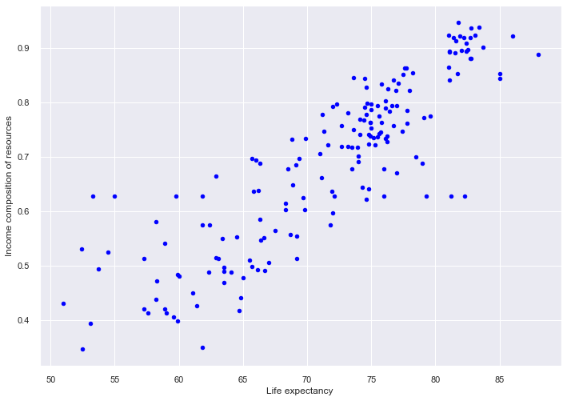

```python
#Do graphs of y against the x-axis and see if there is a variable I can transform
#Only select the year 2015 for the scatter plot

#Subsetting by the year 2015
rslt_df = lifeexp_continent[lifeexp_continent['Year'] == 2015]
#print(rslt_df)

#under_200.plot.scatter('Life expectancy ','infant deaths')
rslt_df.plot.scatter('Life expectancy ','Income composition of resources', c='blue')#keep these variable
```

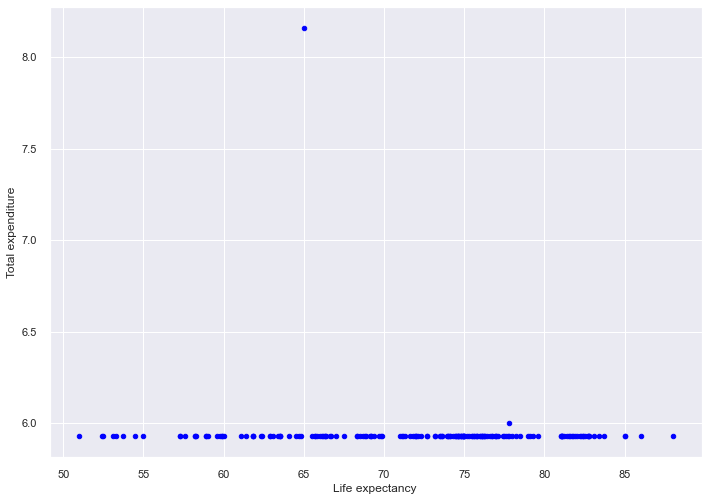

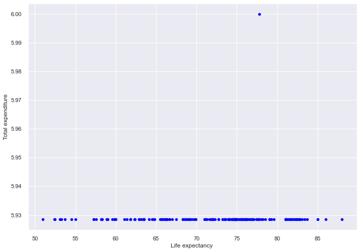

```python
rslt_df.plot.scatter('Life expectancy ','Total expenditure',c='blue')#no relationship
under_8 = rslt_df[rslt_df['Total expenditure']< 6.5]
under_8.plot.scatter('Life expectancy ','Total expenditure',c='blue')
```

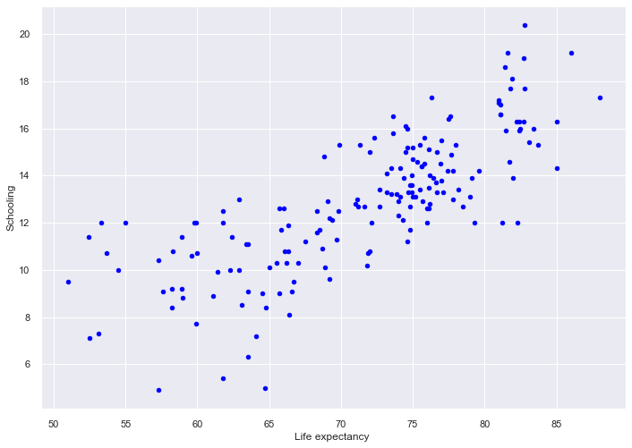

```python
rslt_df.plot.scatter('Life expectancy ','Schooling',c='blue')#keep this variable
```

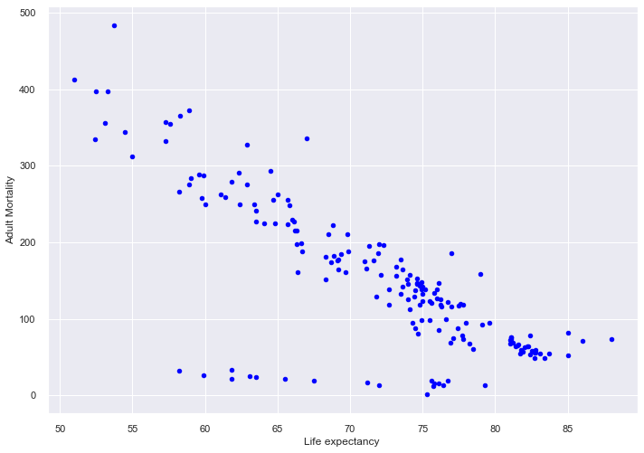

```python
rslt_df.plot.scatter('Life expectancy ','Adult Mortality',c='blue')
```

```python
#Linear regression on schooling and adult mortality

from sklearn.model_selection import train_test_split

X = lifeexp_continent[['Adult Mortality','Schooling']]
y = lifeexp_continent[['Life expectancy ']]

X_train, X_test, y_train, y_test = train_test_split(X, y, test_size=0.33)

## fit a OLS model with training data
X = sm.add_constant(X_train)
est = sm.OLS(y_train, X).fit()
est.summary()

## fit a OLS model with testing data
X = sm.add_constant(X_test)
est = sm.OLS(y_test, X).fit()
est.summary()
```

OLS Regression Results

| Dep. Variable: | Life expectancy | R-squared: | 0.701 |
| --- | --- | --- | --- |
| Model: | OLS | Adj. R-squared: | 0.701 |
| Method: | Least Squares | F-statistic: | 1089. |
| Date: | Thu, 28 Oct 2021 | Prob (F-statistic): | 5.23e-244 |
| Time: | 14:46:42 | Log-Likelihood: | -2842.3 |
| No. Observations: | 930 | AIC: | 5691. |
| Df Residuals: | 927 | BIC: | 5705. |
| Df Model: | 2 |  |  |
| Covariance Type: | nonrobust |  |  |

|  | coef | std err | t | P>\|t\| | [0.025 | 0.975] |
| --- | --- | --- | --- | --- | --- | --- |
| const | 56.1318 | 0.854 | 65.712 | 0.000 | 54.455 | 57.808 |
| Adult Mortality | -0.0344 | 0.002 | -21.750 | 0.000 | -0.037 | -0.031 |
| Schooling | 1.5875 | 0.058 | 27.520 | 0.000 | 1.474 | 1.701 |

| Omnibus: | 169.068 | Durbin-Watson: | 1.964 |
| --- | --- | --- | --- |
| Prob(Omnibus): | 0.000 | Jarque-Bera (JB): | 620.624 |
| Skew: | -0.833 | Prob(JB): | 1.71e-135 |
| Kurtosis: | 6.638 | Cond. No. | 1.01e+03 |

Notes:  
[1] Standard Errors assume that the covariance matrix of the errors is correctly specified.  
[2] The condition number is large, 1.01e+03. This might indicate that there are  
strong multicollinearity or other numerical problems.

```python
#Import VIF package from statsmodel
from statsmodels.stats.outliers_influence import variance_inflation_factor

#VIF on linear model

X = lifeexp_continent[['Adult Mortality','Schooling']]
vif_data = pd.DataFrame()
vif_data["feature"] = X.columns

# calculating VIF for each feature
vif_data["VIF"] = [variance_inflation_factor(X.values, i)
                          for i in range(len(X.columns))]

print(vif_data)
```

```
           feature       VIF
0  Adult Mortality  1.948454
1        Schooling  1.948454
```

There is a moderate correlation between Adult Mortality and Schooling

```python
#Linear regression on schooling and income composition of re
X = lifeexp_continent[['Income composition of resources','Schooling']]
y = lifeexp_continent[['Life expectancy ']]

## fit a OLS model
X = sm.add_constant(X)
est = sm.OLS(y, X).fit()
est.summary()
```

OLS Regression Results

| Dep. Variable: | Life expectancy | R-squared: | 0.560 |
| --- | --- | --- | --- |
| Model: | OLS | Adj. R-squared: | 0.560 |
| Method: | Least Squares | F-statistic: | 1792. |
| Date: | Thu, 28 Oct 2021 | Prob (F-statistic): | 0.00 |
| Time: | 14:46:56 | Log-Likelihood: | -9215.2 |
| No. Observations: | 2816 | AIC: | 1.844e+04 |
| Df Residuals: | 2813 | BIC: | 1.845e+04 |
| Df Model: | 2 |  |  |
| Covariance Type: | nonrobust |  |  |

|  | coef | std err | t | P>\|t\| | [0.025 | 0.975] |
| --- | --- | --- | --- | --- | --- | --- |
| const | 43.5660 | 0.456 | 95.527 | 0.000 | 42.672 | 44.460 |
| Income composition of resources | 15.4178 | 0.965 | 15.981 | 0.000 | 13.526 | 17.310 |
| Schooling | 1.3310 | 0.061 | 21.864 | 0.000 | 1.212 | 1.450 |

| Omnibus: | 249.371 | Durbin-Watson: | 0.272 |
| --- | --- | --- | --- |
| Prob(Omnibus): | 0.000 | Jarque-Bera (JB): | 986.305 |
| Skew: | -0.364 | Prob(JB): | 6.71e-215 |
| Kurtosis: | 5.807 | Cond. No. | 101. |

Notes:  
[1] Standard Errors assume that the covariance matrix of the errors is correctly specified.

```python
#VIF on linear model
X = lifeexp_continent[['Income composition of resources','Schooling']]
vif_data = pd.DataFrame()
vif_data["feature"] = X.columns

# calculating VIF for each feature
vif_data["VIF"] = [variance_inflation_factor(X.values, i)
                          for i in range(len(X.columns))]

print(vif_data)
```

```
                           feature        VIF
0  Income composition of resources  28.063278
1                        Schooling  28.063278
```

There are instances of high multicollinearity (variables related to each other). The p-values and t-values are not trustworthy when there is high multicollinearity Will use only variables with low multicollinearity.

# Forward and backward regression

https://datascience.stackexchange.com/questions/24405/how-to-do-stepwise-regression-using-sklearn/24447#24447 Website were code was obtained

```python
#Stepwise regression
#Forward then backward regression
import statsmodels.api as sm
from sklearn.model_selection import train_test_split
X =  lifeexp_continent[['Status','Adult Mortality','Alcohol','percentage expenditure','Hepatitis B','Measles ',' BMI ',
                        'Polio','Total expenditure','Diphtheria ',' HIV/AIDS','GDP','Population','Schooling']]

y = lifeexp_continent[['Life expectancy ']]
X_train, X_test, y_train, y_test = train_test_split(X, y, test_size=0.33)

def forward_selection(X, y,
                           initial_list=[],
                           threshold_in=0.01,
                           threshold_out = 0.05,
                           verbose=True):
    included = list(initial_list)
    while True:
        changed=False
        # forward step
        excluded = list(set(X.columns)-set(included))
        new_pval = pd.Series(index=excluded,dtype='float64')
        for new_column in excluded:
            model = sm.OLS(y, sm.add_constant(pd.DataFrame(X[included+[new_column]]))).fit()
            new_pval[new_column] = model.pvalues[new_column]
        best_pval = new_pval.min()
        if best_pval < threshold_in:
            best_feature = new_pval.idxmin()
            included.append(best_feature)
            changed=True
            if verbose:
                print('Add  {:30} with p-value {:.6}'.format(best_feature, best_pval))


        if not changed:
            break
    return included


result = forward_selection(X_train, y_train)

print('resulting features:')
print(result)

#print(X,y)
```

```
Add  Adult Mortality                with p-value 3.56701e-288
Add  Schooling                      with p-value 6.87127e-200
Add   HIV/AIDS                      with p-value 2.14115e-70
Add  Diphtheria                     with p-value 1.58602e-52
Add   BMI                           with p-value 1.02227e-23
Add  Status                         with p-value 5.82389e-16
Add  Polio                          with p-value 2.41772e-10
Add  GDP                            with p-value 1.83257e-08
Add  Measles                        with p-value 1.36459e-06
Add  Hepatitis B                    with p-value 2.34903e-05
Add  Total expenditure              with p-value 0.00820567
resulting features:
['Adult Mortality', 'Schooling', ' HIV/AIDS', 'Diphtheria ', ' BMI ', 'Status', 'Polio', 'GDP', 'Measles ', 'Hepatitis B', 'Total expenditure']
```

```python
whos
```

[output not shown]

With forward regression the variables to add would be Schooling, Adult mortality, and HIV/AIDS. Forward regression adds the variables one at a time while backwards removes then one at a a time.

```python
#Backward regression
def backward_regression(X, y,
                           initial_list=[],
                           threshold_in=0.01,
                           threshold_out = 0.05,
                           verbose=True):
    included=list(X.columns)
    while True:
        changed=False
        model = sm.OLS(y, sm.add_constant(pd.DataFrame(X[included]))).fit()
        # use all coefs except intercept
        pvalues = model.pvalues.iloc[1:]
        worst_pval = pvalues.max() # null if pvalues is empty
        if worst_pval > threshold_out:
            changed=True
            worst_feature = pvalues.idxmax()
            included.remove(worst_feature)
            if verbose:
                print('Drop {} with p-value {}'.format(worst_feature, worst_pval))
        if not changed:
            break
    return included

backward_regression(X_train, y_train)
```

```
Drop percentage expenditure with p-value 0.6118379211767214
Drop Population with p-value 0.493997692589181
Drop Alcohol with p-value 0.05366621942143233
```

```
['Status',
 'Adult Mortality',
 'Hepatitis B',
 'Measles ',
 ' BMI ',
 'Polio',
 'Total expenditure',
 'Diphtheria ',
 ' HIV/AIDS',
 'GDP',
 'Schooling']
```

In the backward regression variables are removed and the ones that are the most important are the end. The top three in this regression HIV/AIDS, GDP, and Schooling.

```python
#Linear regression on schooling and adult mortality

X = lifeexp_continent[['Adult Mortality','Schooling', ' HIV/AIDS']]
y = lifeexp_continent[['Life expectancy ']]

X_train, X_test, y_train, y_test = train_test_split(X, y, test_size=0.33)
## fit a OLS model with training data
X = sm.add_constant(X_train)
est = sm.OLS(y_train, X).fit()
est.summary()

## fit a OLS model with testing data
X = sm.add_constant(X_test)
est = sm.OLS(y_test, X).fit()
est.summary()
```

OLS Regression Results

| Dep. Variable: | Life expectancy | R-squared: | 0.760 |
| --- | --- | --- | --- |
| Model: | OLS | Adj. R-squared: | 0.760 |
| Method: | Least Squares | F-statistic: | 980.1 |
| Date: | Thu, 28 Oct 2021 | Prob (F-statistic): | 9.04e-287 |
| Time: | 14:47:26 | Log-Likelihood: | -2751.7 |
| No. Observations: | 930 | AIC: | 5511. |
| Df Residuals: | 926 | BIC: | 5531. |
| Df Model: | 3 |  |  |
| Covariance Type: | nonrobust |  |  |

|  | coef | std err | t | P>\|t\| | [0.025 | 0.975] |
| --- | --- | --- | --- | --- | --- | --- |
| const | 56.1473 | 0.754 | 74.434 | 0.000 | 54.667 | 57.628 |
| Adult Mortality | -0.0237 | 0.002 | -14.956 | 0.000 | -0.027 | -0.021 |
| Schooling | 1.4955 | 0.051 | 29.602 | 0.000 | 1.396 | 1.595 |
| HIV/AIDS | -0.5615 | 0.037 | -15.237 | 0.000 | -0.634 | -0.489 |

| Omnibus: | 70.188 | Durbin-Watson: | 1.948 |
| --- | --- | --- | --- |
| Prob(Omnibus): | 0.000 | Jarque-Bera (JB): | 285.578 |
| Skew: | -0.211 | Prob(JB): | 9.72e-63 |
| Kurtosis: | 5.682 | Cond. No. | 1.01e+03 |

Notes:  
[1] Standard Errors assume that the covariance matrix of the errors is correctly specified.  
[2] The condition number is large, 1.01e+03. This might indicate that there are  
strong multicollinearity or other numerical problems.

```python
#p values of scaled data
#Does not have values that were shown to always have high VIF values
#Finding out which variables
from statsmodels.stats.outliers_influence import variance_inflation_factor
# VIF dataframe


X = lifeexp_continent[['Adult Mortality','Schooling', ' HIV/AIDS']]
vif_data = pd.DataFrame()
vif_data["feature"] = X.columns

# calculating VIF for each feature
vif_data["VIF"] = [variance_inflation_factor(X.values, i)
                          for i in range(len(X.columns))]

print(vif_data)
```

```
           feature       VIF
0  Adult Mortality  2.787062
1        Schooling  2.049733
2         HIV/AIDS  1.533226
```

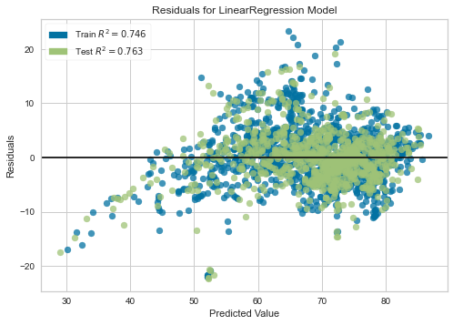

```python
df1 =lifeexp_continent.loc[:,("Adult Mortality", "Schooling",' HIV/AIDS')]
life_expectancy = lifeexp_continent[['Life expectancy ']]

from sklearn.linear_model import LinearRegression
from sklearn.model_selection import train_test_split


from yellowbrick.regressor import ResidualsPlot

X_train, X_test, y_train, y_test = train_test_split(df1, life_expectancy, test_size=0.33)

model = LinearRegression()
visualizer = ResidualsPlot(model, hist=False)

visualizer.fit(X_train, y_train)  # Fit the training data to the visualizer
visualizer.score(X_test, y_test)  # Evaluate the model on the test data
visualizer.show()
```